## Homework 9

#### Due Friday, April 2, 11:59 PM CT

### 1

- Read in the `chimpanzee.csv` data file.
- Consider only those trials with a partner.
- Make an assumption that there is a universal $p_{\text{partner}}$ representing the probability any chimpanzee would make a prosocial choice in a single trial under the experimental conditions we have been examining.
- Assume that all trials are independent.

```r
chimpanzee <- read_csv("../../data/chimpanzee.csv")
with_partner <- chimpanzee%>%
  filter(partner != "none")
```

*(a)* Under these assumptions, write down a statistical model for $X_1$, the total number of prosocial choices made with a partner present in this experiment.

```r
with_partner%>%
  summarize(
    prosocial = sum(prosocial)
  )
```

```
## # A tibble: 1 x 1
##   prosocial
##       <dbl>
## 1       359
```

*(b)* Test the hypothesis that $p_{\text{partner}} = 0.5$ versus the two-sided alternative. Report a p-value.

```r
with_partner<-with_partner %>%
  summarise(prosocial=sum(prosocial),
            selfish=sum(selfish),
            total=prosocial+selfish,
            p = prosocial/total)
tol <- 1.0e-07
x <- 0:with_partner$total
x_extreme <- x[dbinom(x,with_partner$total,0.5) < dbinom(with_partner$prosocial,with_partner$total,0.5)+tol]
p_value <- sum(dbinom(x_extreme,with_partner$total,0.5))
p_value
```

```
## [1] 1.405895e-05
```

*(c)* Create a graph that shows the sampling distribution of $X_1$ under the null hypothesis and indicates (with different colors and/or lines) how the p-value relates to the graph.

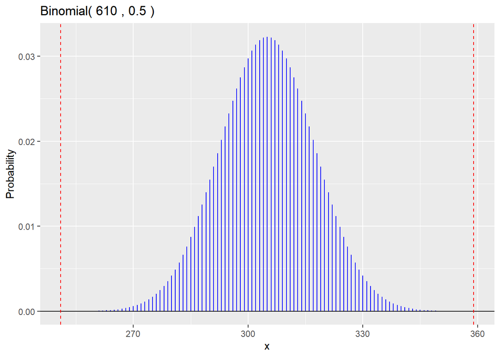

```r
gbinom(with_partner$total, 0.5, scale = TRUE,size=0.5) +
  geom_vline(xintercept = with_partner$prosocial, color = "red", linetype = "dashed") +
  geom_vline(xintercept = 610 * 0.5 + (610 * 0.5 - with_partner$prosocial), color = "red", linetype = "dashed")
```

*(d)* Interpret the results of the hypothesis test in context. -The p_value is 1.405895e-05, which is less than 0.05, which is statistically significant. There is strong evidence that the null hypothesis is wrong, and the true value of p is closer to the observed ratio of p^≈0.589=359/610. p is not 0.5, we just observed typical data, which is more credible than p=0.5, we saw a very unlikely result. There is very strong evidence (p≈0.000014, two-sided binomial test) that in an experimental environment, chimpanzees will make pro-social choices more than half of the time.

### 2

Repeat the previous problem, but use the data for all trials **without** a partner for an assumed universal parameter $p_{\text{no partner}}$, using a statistical model for $X_2$, the total number of prosocial choices made without a partner present in the experiment.

```r
without_partner <- chimpanzee%>%
  filter(partner=="none")%>%
  summarise(
    prosocial = sum(prosocial),
    selfish = sum(selfish),
    total = prosocial + selfish,
    p = prosocial / total
  )
without_partner
```

```
## # A tibble: 1 x 4
##   prosocial selfish total     p
##       <dbl>   <dbl> <dbl> <dbl>
## 1        83      97   180 0.461
```

```r
x2 <- 0:without_partner$total
x_extreme2 <- x[dbinom(x2,without_partner$total,0.5) < dbinom(without_partner$prosocial,without_partner$total,0.5)+tol]
p_value2 <- sum(dbinom(x_extreme2,without_partner$total,0.5))
p_value2
```

```
## [1] 0.3325791
```

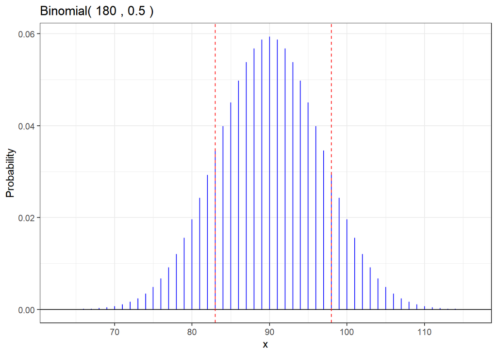

```r
gbinom(without_partner$total,0.5,scale=TRUE,size=0.5)+
  geom_vline(xintercept = 180 * 0.5 + (180 * 0.5 - 82), color = "red", linetype = "dashed")+
  geom_vline(xintercept = without_partner$prosocial,color="red",linetype="dashed",size=0.5)+
  theme_bw()
```

- Suppose the number of prosocial behaviors among chimpanzees without a partner $X_1$ is a binomial distribution with n samples and a long-run probability of chimpanzees’ prosocial behavior p. $X_2 \sim \text{Binomial}(n, p_{\text{no_partner}})$ - This case make hypothesis $H_0=0.5$ and $H_a\not=0.5$ - And we have statistic $n=180$, $p_{\text{no_partner}}=0.5$, so that $X_2 \sim \text{Binomial}(180,0.5)$ - p-value = 0.3325791 - Since the p-value > 0.05, it fails to reject the null hypothesis. There is no evidence in this sample of data to suggest that we should reject the null hypothesis that the probability of choosing a prosocial choice without a partner is 0.5.

### 3

State two criticisms of the assumptions made for the previous two hypothesis tests where reality may differ from the assumptions, possibly leading to misleading conclusions.

- The test does not control all the variate, the color of tokens may also affect choices by chimpanzees, so each trails may not be independent.
- The sample size of the test is still not large enough so the conclusion may not apply to universal situation.

### 4

In questions 1 and 2, we considered two population proportions: $p_{\text{partner}}$ and $p_{\text{no partner}}$. It is sometimes of interest to estimate the *difference* in sample proportions rather than just the individual population proportions. Confidence intervals can be defined for this purpose.

*(a)* Using the Wald estimates, define an 80% confidence for the difference in the population proportions $p_{\text{partner}} - p_{\text{no partner}}$.

```r
chimp <- chimpanzee %>%
  mutate(with_partner=case_when(partner!="none"~"TRUE",TRUE~"FALSE"))%>%
  group_by(with_partner)%>%
  summarise(prosocial = sum(prosocial),
            selfish = sum(selfish),
            n = prosocial + selfish,
            p_hat = prosocial / n,
            se = sqrt(p_hat * (1-p_hat)/n))
chimp
```

```
## # A tibble: 2 x 6
##   with_partner prosocial selfish     n p_hat     se
## * <chr>            <dbl>   <dbl> <dbl> <dbl>  <dbl>
## 1 FALSE               83      97   180 0.461 0.0372
## 2 TRUE               359     251   610 0.589 0.0199
```

```r
est_c_diff <- chimp$p_hat[2] - chimp$p_hat[1]
se_c_diff<-sqrt(chimp$se[2]^2 + chimp$se[1]^2)
z <- abs(qnorm((1-0.8)/2))
ci_c_diff<-est_c_diff + c(-1,1)*z*se_c_diff
ci_c_diff
```

```
## [1] 0.0733831 0.1814439
```